# Analysis of Company Website Traffic

2023-03-14

## Abstract

It has been suggested that dwell times on webpages may be modeled using a Weibull distribution, and that Web browsing exhibits a significant “negative ageing” phenomenon, that is, the rate of Webpage abandonment decreases over time (Liu, White, and Dumais 2010). The goal of this project is to assess the suitability of the normal and Weibull distributions for modeling the average session duration of visitors to a specific website `(http://www.polygraphis.com)`, and to determine whether average session durations for this website have a negative ageing effect. Furthermore, we classify visitors by the region they come from and use a hierarchical Weibull model to study the average session duration of visitors from each region. We then fit the model using JAGS and R and perform convergence diagnostics as well as residual analysis, and assess predictive performance of the model. These results are then compared to those obtained by fitting a normal distribution to the data.

## Introduction

The main questions addressed are: first, is the Weibull distribution appropriate for modeling the average session duration of visitors to the website `http://www.polygraphis.com`; second, do average session durations on this website exhibit a negative ageing effect? We propose to analyze the daily average session duration of visitors, classified by geographic region, that arrived at the website via organic search from 6 March 2021 to 12 March 2023. We will apply a hierarchical model to the data, where each region has its own Weibull distribution with a common normal distribution on the shape parameter and a gamma distribution $\Gamma(\alpha,\beta)$ on the scale parameter such that the mean $\frac{\alpha}{\beta}$ and standard deviation $\frac{\sqrt{\alpha}}{\beta}$ are modeled by gamma distributions themselves. Using JAGS and R, we will then fit the model and address the first question by performing convergence diagnostics as well as assessing predictive performance. The second question will be addressed by determining the hazard function of the distribution for each region using the mean parameters of the model obtained.

## Data

The data were collected from the company’s Google Analytics account. The head of the extracted raw dataset is show below.

```
##   Continent     Date Users Avg..Session.Duration
## 1      Asia 20220429    70              00:01:53
## 2      Asia 20220430    65              00:02:16
## 3      Asia 20210514    50              00:01:30
## 4      Asia 20210512    49              00:01:00
## 5      Asia 20220428    42              00:01:29
## 6      Asia 20210420    41              00:01:36
```

The dataset only included organic search traffic. A *session* is defined to be a period of time during which a user interacts with the website; it is initiated when a user that is currently not in any active session views a page,and it ends after 30 minutes of user inactivity, when the user enters the last page without an engagement hit, or at the moment of the last engagement hit on the last page. The *average session duration* for a given date and continent is calculated by dividing the total duration of all sessions on that date of users from the given continent by the corresponding number of sessions (“Session Duration, Avg - Analytics Help” 2023). The average session durations in the dataset were converted into seconds, and only rows with a well-defined continent (one of the 5 continents - Africa, Americas, Asia, Europe or Oceania) and an average session duration of at least two seconds were kept. Each continent was converted into a number which denoted its position in the lexicographical ordering of all 5 continents (so Africa was mapped to 1, Americas to 2, Asia to 3, Europe to 4 and Oceania to 5). The cleaned dataset had 1128 rows and 2 columns, one for the continent and the other for the average session duration (in seconds). As a side note, we remark that the dwell times considered by (Liu, White, and Dumais 2010) are calculated for single webpages and not for whole sessions.

```
##   Continent_number average_session_duration
## 1                3                      113
## 2                3                      136
## 3                3                       90
## 4                3                       60
## 5                3                       89
## 6                3                       96
```

Before taking into account the distribution of the average session durations across different regions, we observed that the density line of the data appeared to increase sharply at first, and after reaching its peak seemed to approximately follow a Weibull distribution with negative ageing. The boxplots showed the presence of quite a few outliers for each continent.

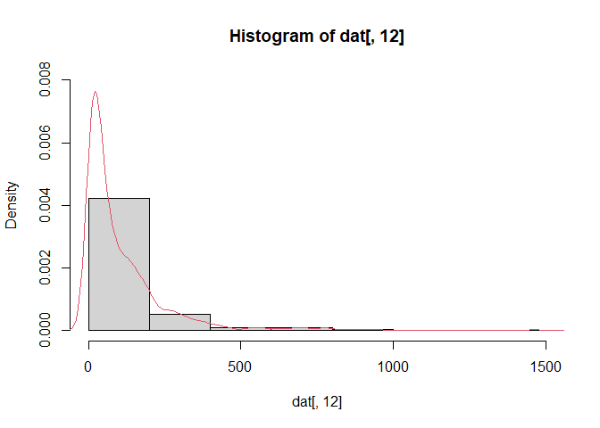

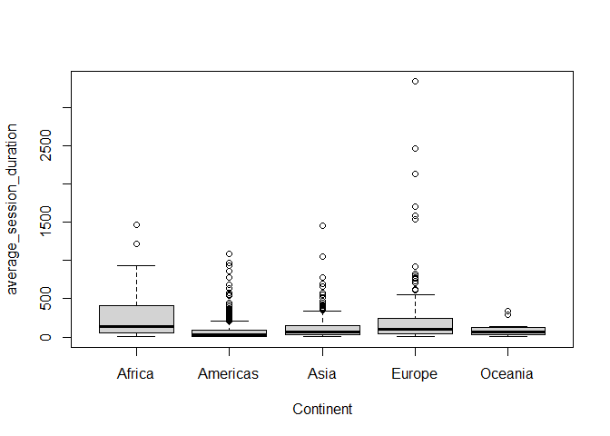

## Model

The Weibull distribution seems to be quite a natural model for dwell times on webpages. The idea is that web users often quickly scan through a webpage for relevance; they abandon it as soon as they discover that it is irrelevant, but are more likely to stay on after the short window for assessing its relevance is over and when they dwell longer on the webpage. The full hierarchical Weibull model is specified in the following code.

```r
mod_string = " model {
for (i in 1:length(Continent)) {
  average_session_duration[i] ~ dweib(v,lam[Continent[i]])
}

for (j in 1:5) {
  lam[j] ~ dgamma(alpha, beta)
  mu[j] = (exp(loggam(1+1/v)))*lam[j]^(-1/v)
}

alpha = mu0^2 / sig0^2
beta = mu0 / sig0^2
v ~ dnorm(3.0,1.0)

mu0 ~ dgamma(.1, 10.0)
sig0 ~ dgamma(.1,10.0)

} "
```

Having specified the model, we set a seed of 113 and fitted the model using JAGS and R. The monitored parameters were $v$, $\mu$, $\lambda$, $\mu_0$ and $\sigma_0$ ($\mu$ and $\lambda$ are vectors of length 5, where each coordinate corresponds to a continent). The algorithm was run for three chains with a burn-in period of 1000 iterations, and each chain was run for 1e4 iterations. It was observed that convergence for each parameter was achieved after 1e4 iterations. The Gelman-Rubin diagnostic potential reduction factor for every parameter except $\mu_0$ and $\sigma_0$ also converged to $1$; the shrink factor for $\mu_0$ reduced to between 1.03 and 1.09 while that for $\sigma_0$ reduced to between 1.07 and 1.15. The trace, density and autocorrelation plots for $\lambda_1$ and $v$ (for all three chains) are shown below.

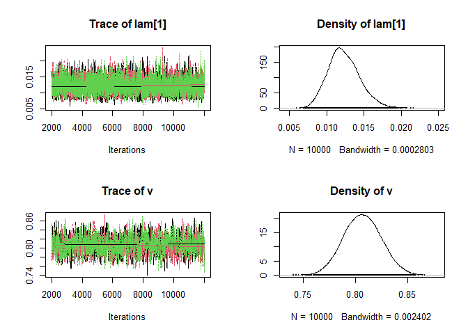

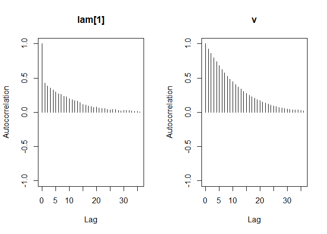

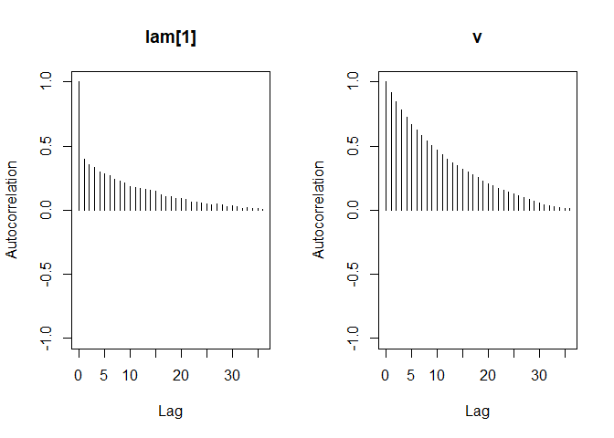

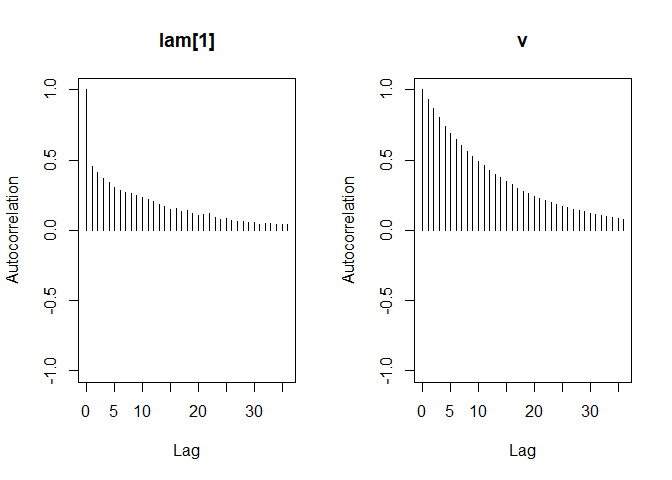

We also calculated a value of 12848 for the Deviance Information Criterion (DIC); this value would later be compared to the DIC value obtained for the alternative, normal model.

In order to carry out residual analysis, we divided all the daily average session durations into 5 sublists, one for each of the 5 continents, and subtracted the mean average session duration $\mu_i$ for each continent $i$ from every element in the corresponding sublist for continent $i$. The residual plots are shown below.

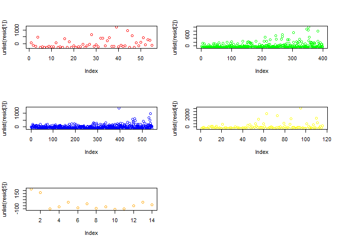

The mean as well as the standard deviation of the residuals for the 5 continents are listed below in ascending order of the continent indices.

```
## Mean residuals: 7.408088 3.143734 -2.709144 19.73206 -21.34391
```

```
## Standard deviation of residuals: 327.9693 144.0456 127.6912 501.8171 99.26842
```

Apart from the presence of outliers, there did not appear to be any unusual patterns in the residual plots. We also compared the continent average session duration means to the overall mean average session duration. The latter was calculated using the formula $\mu = \Gamma(1+\frac{1}{v})\cdot\mu_0^{-\frac{1}{v}}$; here $\mu_0$ denotes the overall mean of the scale parameter $\lambda$. The plot of the differences $\mu_i - \mu$ for $i \in \{1,2,3,4,5\}$ is shown below.

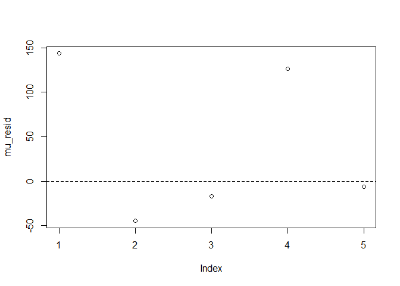

```
##           0%           5%          10%          15%          20%          25%
## 4.925311e+00 5.226436e+01 6.729470e+01 7.889940e+01 8.867935e+01 9.797797e+01
##          30%          35%          40%          45%          50%          55%
## 1.072029e+02 1.164754e+02 1.259678e+02 1.358672e+02 1.460714e+02 1.576500e+02
##          60%          65%          70%          75%          80%          85%
## 1.708787e+02 1.861141e+02 2.047261e+02 2.292162e+02 2.629486e+02 3.134105e+02
##          90%          95%         100%
## 4.017439e+02 6.420759e+02 1.101838e+10
```

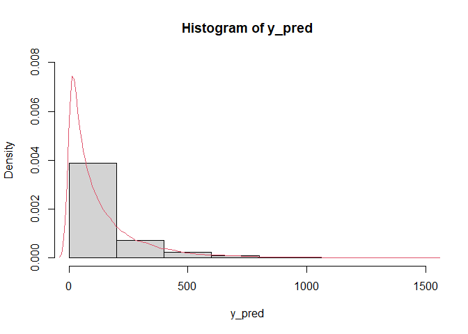

For comparison, we tried fitting an alternative model to the data using the normal distribution. The mean and precision were modeled using gamma distributions. The mean and standard deviation of the parameters of the mean distribution were also modeled using gamma distributions.

```r
mod1_string = " model {
for (i in 1:length(Continent)) {
  average_session_duration[i] ~ dnorm(mu[Continent[i]],prec[Continent[i]])
}

for (j in 1:5) {
  mu[j] ~ dgamma(alpha, beta)
  prec[j] ~ dgamma(50.0, 5*1.0/2.0)

}

alpha = mu0^2 / sig0^2
beta = mu0 / sig0^2
sig = 1/sqrt(prec)

mu0 ~ dgamma(124.0, 1.0)
sig0 ~ dgamma(50.0,1/10.0)


} "
```

As was the case for the Weibull model, convergence was observed after 1e4 iterations. However, it was observed that even though the DIC value for the normal model was 14821 - larger than the DIC value of 12848 for the Weibull model, the mean residuals were smaller in the normal model, as shown below.

```
## Mean residuals: 3.107182 0.5004386 0.2314226 4.925634 0.8873818
```

```
## Standard deviation of residuals: 327.9693 144.0456 127.6912 501.8171 99.26842
```

```
##           0%           5%          10%          15%          20%          25%
## 2.461246e-70 3.950732e-12 1.875661e-08 2.382546e-06 6.067019e-05 6.312026e-04
##          30%          35%          40%          45%          50%          55%
## 4.814906e-03 2.358775e-02 9.837904e-02 3.422679e-01 1.021179e+00 2.651651e+00
##          60%          65%          70%          75%          80%          85%
## 6.124312e+00 1.322977e+01 2.629759e+01 5.067304e+01 9.773452e+01 1.870319e+02
##          90%          95%         100%
## 3.584605e+02 7.673775e+02 8.125360e+03
```

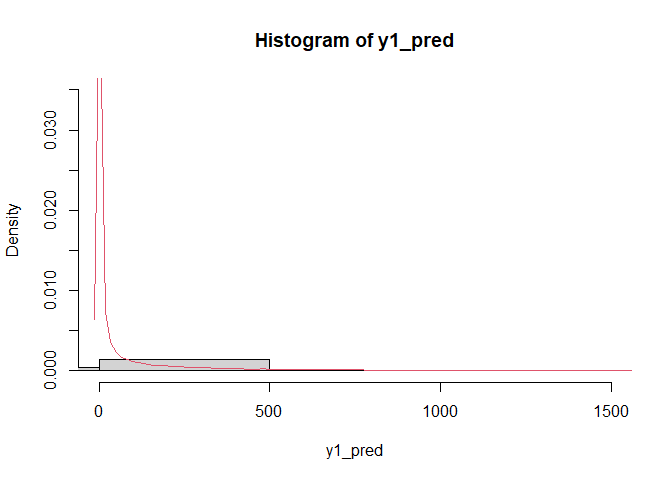

## Results and Conclusions

The following is the summary of the posterior distribution for the Weibull model.

```
##
## Iterations = 1:30000
## Thinning interval = 1
## Number of chains = 1
## Sample size per chain = 30000
##
## 1. Empirical mean and standard deviation for each variable,
##    plus standard error of the mean:
##
##             Mean        SD  Naive SE Time-series SE
## lam[1]   0.01233  0.002106 1.216e-05      4.207e-05
## lam[2]   0.03156  0.003229 1.864e-05      8.646e-05
## lam[3]   0.02501  0.002474 1.428e-05      6.940e-05
## lam[4]   0.01287  0.001847 1.067e-05      4.383e-05
## lam[5]   0.02461  0.006270 3.620e-05      7.416e-05
## mu[1]  270.37373 45.117337 2.605e-01      2.779e-01
## mu[2]   82.37757  5.147051 2.972e-02      3.039e-02
## mu[3]  109.78451  5.873736 3.391e-02      3.288e-02
## mu[4]  253.11277 29.080277 1.679e-01      1.713e-01
## mu[5]  121.05819 37.942140 2.191e-01      2.463e-01
## mu0      0.02211  0.006024 3.478e-05      1.178e-04
## sig0     0.01105  0.006269 3.619e-05      1.343e-04
##
## 2. Quantiles for each variable:
##
##             2.5%       25%       50%       75%     97.5%
## lam[1] 8.627e-03 1.087e-02   0.01216   0.01365   0.01685
## lam[2] 2.565e-02 2.928e-02   0.03142   0.03369   0.03831
## lam[3] 2.045e-02 2.327e-02   0.02494   0.02666   0.03008
## lam[4] 9.619e-03 1.156e-02   0.01276   0.01404   0.01677
## lam[5] 1.418e-02 2.018e-02   0.02396   0.02841   0.03866
## mu[1]  1.948e+02 2.386e+02 266.03557 296.85702 370.52671
## mu[2]  7.289e+01 7.885e+01  82.18561  85.75120  92.96505
## mu[3]  9.893e+01 1.057e+02 109.56840 113.63023 121.72710
## mu[4]  2.020e+02 2.326e+02 250.95725 271.22002 315.82131
## mu[5]  6.563e+01 9.426e+01 114.83037 140.78799 211.55330
## mu0    1.306e-02 1.825e-02   0.02129   0.02490   0.03662
## sig0   4.762e-03 7.258e-03   0.00943   0.01278   0.02739
## v      7.725e-01 7.944e-01   0.80659   0.81893   0.84200
```

Here is the summary of the posterior distribution for the normal model.

```
##
## Iterations = 1:30000
## Thinning interval = 1
## Number of chains = 1
## Sample size per chain = 30000
##
## 1. Empirical mean and standard deviation for each variable,
##    plus standard error of the mean:
##
##          Mean     SD Naive SE Time-series SE
## mu[1]  274.67 26.659  0.15391        0.19474
## mu[2]   85.02  6.524  0.03766        0.04803
## mu[3]  106.84  5.020  0.02898        0.03629
## mu[4]  267.92 34.250  0.19774        0.24176
## mu[5]   98.83  9.007  0.05200        0.06496
## mu0    132.03 11.315  0.06533        0.08324
## sig[1] 195.17 11.129  0.06425        0.06479
## sig[2] 128.97  4.098  0.02366        0.02366
## sig[3] 117.49  3.287  0.01898        0.01898
## sig[4] 368.09 17.825  0.10291        0.10291
## sig[5]  33.88  2.266  0.01308        0.01324
## sig0   420.41 63.298  0.36545        0.48126
##
## 2. Quantiles for each variable:
##
##          2.5%    25%    50%    75%  97.5%
## mu[1]  221.93 256.71 274.69 292.67 326.76
## mu[2]   72.20  80.66  85.00  89.44  97.89
## mu[3]   96.86 103.47 106.80 110.22 116.73
## mu[4]  200.77 244.92 267.85 291.00 334.76
## mu[5]   81.09  92.77  98.89 104.79 116.60
## mu0    110.79 124.23 131.70 139.58 155.04
## sig[1] 174.85 187.37 194.59 202.40 218.30
## sig[2] 121.20 126.19 128.84 131.65 137.36
## sig[3] 111.26 115.22 117.42 119.66 124.18
## sig[4] 335.08 355.74 367.31 379.57 405.03
## sig[5]  29.81  32.30  33.73  35.32  38.71
## sig0   305.41 376.11 417.27 460.90 553.64
```

Finally, the second question of this project may be answered by looking at the mean value of the shape parameter $v$ as well as the mean value of the scale parameter $\lambda_i$ ($i \in \{1,2,3,4,5\}$) for each of the 5 continents. The hazard function of the Weibull distribution with shape parameter $v$ and scale parameter $\lambda$ is given by $h(t) = v\lambda_it^{v-1}$, and $h(t)$ is a positive decreasing function iff $v < 1$ and $\lambda_i > 0$. The plots below show that the hazard functions for all 5 distributions are indeed decreasing, thus confirming the phenomenon of negative ageing.

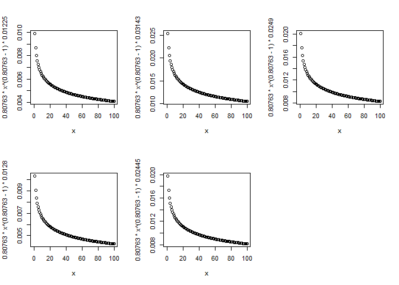

As briefly mentioned earlier, one caveat is that the Weibull model we fitted has quite a number of outliers. Furthermore, a limitation of the model is that the shape parameter $v$ follows a normal distribution with fixed parameters. It might be reasonable to allow the parameters of the distribution of $v$ to have distributions themselves, thus reflecting the variability of the mean values of $v$ for the different continents. Another possible improvement is to consider fitting a mixed model, for example a mixture of two Weibull distributions, which might reduce the residual errors.

## References

Fink, Daniel. 1997. “A Compendium of Conjugate Priors.” https://www.johndcook.com/CompendiumOfConjugatePriors.pdf.

Liu, Chao, Ryen W. White, and Susan Dumais. 2010. “Understanding Web Browsing Behaviors Through Weibull Analysis of Dwell Time.” In *Proceedings of the 33rd International ACM SIGIR Conference on Research and Development in Information Retrieval*, 379–86. SIGIR ’10. New York, NY, USA: Association for Computing Machinery.

“Session Duration, Avg - Analytics Help.” 2023. https://support.google.com/analytics/answer/1006253.